# Data Science Tutorial - Heart Disease

## Tutorial by Luke Perry

### Motivation

Heart disease causes 1 in every 4 deaths according to the [cdc](https://www.cdc.gov/heartdisease/facts.htm). My grand father recently had a heart attack. Now, my family and I are now all considered "predisposed" and at risk to have heart attacks too. Predicting if someone is at risk for heart disease can start the process of early intervention, and possibly avoid a heart attack or another heart related emergency.

### Tutorial Description

This tutorial will focus on predicting heart disease using modern data science approaches taught in UMD's CMSC320 but are industry standard practices. We will be utilizing modern data science tools to iterate through "The Data Science Pipeline" as outlined in UMD CMCS320. The Data Science Pipeline has 5 stages, and they are data collection, management/representation, exploratory analysis, hypothesis testing/machine learning, and lastly summarizing our insights attained.

### Prerequisites

This tutorial assumes the reader has beginner to intermediate knowledge of Python programming, Jupyter Notebooks, and statistics.

The tools required for this tutorial are Python and Jupyter Notebook. The reader will also need to install the following modules:

1. [numpy](https://numpy.org/) (follow up article at link)
2. [pandas](https://pandas.pydata.org/) (follow up article at link)
3. [matplotlib](https://matplotlib.org/) (follow up article at link)
4. [seaborn](https://seaborn.pydata.org/) (follow up article at link)
5. [statsmodels](https://www.statsmodels.org/stable/index.html) (follow up article at link)
6. [sklearn](https://scikit-learn.org/stable/) (follow up article at link)

### Organization

The tutorial is broken down into 5 parts, each with subheaders that are nested up to 3 levels:

1. Data Collection
   1. Collecting Data
   2. Pandas
   3. Code Walkthrough
2. Data Management/Representation
   1. Dataset Labeling Issues
   2. Dataset Labels
3. Exploratory Data Analysis
   1. Verifying Data
      1. Code Walkthrough
   2. Descriptive Statistics
   3. Correlation Matrix
      1. Code Walkthrough
   4. Violin Plots
      1. Code Walkthrough
      2. Chest Pain VS Heart Disease
      3. Maximum Heart Rate VS Heart Disease
      4. Age VS Heart Disease
      5. Sex VS Heart Disease
      6. Slope of peak exercise ST segment VS Heart Disease
4. Hypothesis Testing and Machine Learning
   1. Hypothesis Testing
      1. Statsmodels
      2. Code Walkthrough
      3. Chest Pain and Resting Heart Rate Linear Regression
      4. Chest Pain and Resting Heart Rate Linear Regression Residuals
      5. Code Walkthrough
      6. Residuals of Chest Pain and Resting Heart Rate Linear Regression grouped by Age
      7. Residuals of Chest Pain and Resting Heart Rate Linear Regression grouped by Sex
      8. Residuals Chest Pain and Resting Heart Rate Linear Regression grouped by Slope of peak exercise ST segment
      9. Chest Pain, Resting Heart Rate, and Sex Linear Regression
      10. Chest Pain, Resting Heart Rate, and Age Linear Regression
      11. Residuals of Chest Pain, Resting Heart Rate, and Sex Linear Regression grouped by Age
      12. Residuals of Chest Pain, Resting Heart Rate, and Age Linear Regression grouped by Sex
      13. Residuals of Chest Pain, Resting Heart Rate, and Sex Linear Regression grouped by Slope of peak exercise ST segment
      14. Residuals of Chest Pain, Resting Heart Rate, and Age Linear Regression grouped by Slope of peak exercise ST segment
   2. Machine Learning
      1. Linear Regression with sklearn
      2. Kfolds Cross-Validation Linear Regression with sklearn
      3. ML Results
5. Communication of insights attained

# Part 1: Data Collection

### 1.1 Collecting Data

Typically the first step to the data science pipeline is [collecting data](https://realpython.com/beautiful-soup-web-scraper-python/) (follow up article at link). The hyperlink leads to an article about scraping data if you're interested in learning more. In the real world, data is never uniform and clean. A lot of data science is just parsing and collecting data. We were lucky enough to find a good dataset, as documented below, but often you'll need to spend a decent chunk of time collecting, parsing, and cleaning data. We will be using a pre-prepared dataset from [Kaggle](http://kaggle.com) (follow up article at link), the self proclaimed "world's largest data science community".

We'll be using a build in pandas function that ingests csv files for us from URLs

### 1.2 Pandas

[pandas](https://pandas.pydata.org/) (follow up article at link) is a modern datascience tool for manipulating and analyzing data. Pandas is built on the concept of a "Dataframe" which is an object in pandas for data manipulation similar to a table. Pandas has a lot of very convenient native features such as slicing, graphing, merging, and is optomized for performance. Pandas is very popular among the datascience community. First, we need to collect our data before we can do anything else.

Another popular alternative is working with/from databases, but Pandas makes it very easy to work with data in Python, and is the "industry standard" however it is limited by the amount of memory on your machine. We aren't working with a large dataset so this isn't a problem. But with larger datasets other tools like databases may have to be used.

### 1.3 Step by Step Code Walk-Through

1. Import all of the required modules. It is best practice to import all of your modules in the first cell of your Jupyter Notebook
1. We're going to be using a popular dataset from [Kaggle](http://kaggle.com) (follow up article at link). Just in case the dataset is removed from Kaggle, I've uploaded a mirrior to my personal [GitHub](https://raw.githubusercontent.com/PerryProjects/DataScienceTutorial/main/heart.csv).
1. Import the data into a pandas dataframe
1. Display the first 10 rows with the head() function

```python
# Import modules needed for the project
import pandas as pd
import numpy as np
import statsmodels.api as sm
import matplotlib.pyplot as plt
from pandas.plotting import scatter_matrix
import seaborn as sn
from matplotlib import pyplot
from matplotlib.pyplot import figure
import sklearn
from sklearn.model_selection import train_test_split
from sklearn.feature_selection import RFE
from sklearn.linear_model import LinearRegression
from sklearn.model_selection import cross_val_score
from sklearn.model_selection import KFold
from sklearn.model_selection import GridSearchCV

# Pandas function to read data
df = pd.read_csv('https://raw.githubusercontent.com/PerryProjects/perryprojects.github.io/main/heart.csv')
# Display the first 10 rows
df.head(10)
```

|  | age | sex | cp | trtbps | chol | fbs | restecg | thalachh | exng | oldpeak | slp | caa | thall | output |
| --- | --- | --- | --- | --- | --- | --- | --- | --- | --- | --- | --- | --- | --- | --- |
| 0 | 63 | 1 | 3 | 145 | 233 | 1 | 0 | 150 | 0 | 2.3 | 0 | 0 | 1 | 1 |
| 1 | 37 | 1 | 2 | 130 | 250 | 0 | 1 | 187 | 0 | 3.5 | 0 | 0 | 2 | 1 |
| 2 | 41 | 0 | 1 | 130 | 204 | 0 | 0 | 172 | 0 | 1.4 | 2 | 0 | 2 | 1 |
| 3 | 56 | 1 | 1 | 120 | 236 | 0 | 1 | 178 | 0 | 0.8 | 2 | 0 | 2 | 1 |
| 4 | 57 | 0 | 0 | 120 | 354 | 0 | 1 | 163 | 1 | 0.6 | 2 | 0 | 2 | 1 |
| 5 | 57 | 1 | 0 | 140 | 192 | 0 | 1 | 148 | 0 | 0.4 | 1 | 0 | 1 | 1 |
| 6 | 56 | 0 | 1 | 140 | 294 | 0 | 0 | 153 | 0 | 1.3 | 1 | 0 | 2 | 1 |
| 7 | 44 | 1 | 1 | 120 | 263 | 0 | 1 | 173 | 0 | 0.0 | 2 | 0 | 3 | 1 |
| 8 | 52 | 1 | 2 | 172 | 199 | 1 | 1 | 162 | 0 | 0.5 | 2 | 0 | 3 | 1 |
| 9 | 57 | 1 | 2 | 150 | 168 | 0 | 1 | 174 | 0 | 1.6 | 2 | 0 | 2 | 1 |

# Part 2: Data Management/Representation

### 2.1 Prerequisite Domain Knowledge Defintions

1. Ventricle): One of two chambers at the bottom of the heart responsible for pumping blood in and out of the heart (follow up article at link)
2. [Angina](https://www.mayoclinic.org/diseases-conditions/angina/symptoms-causes/syc-20369373): A condition marked by severe pain in the chest, often also spreading to the shoulders, arms, and neck, caused by an inadequate blood supply to the heart. (follow up article at link)
3. [Asymptomatic](https://medlineplus.gov/ency/article/002217.htm#:~:text=Asymptomatic%20means%20there%20are%20no,not%20have%20symptoms%20of%20it): Showing no symptoms (follow up article at link)
4. Electrocardiogram: An Electrocardiogram (ECG) is a simple and fast test used to evalaute the heart. Electrodes are placed on the chest, arms, and legs. Then, the electrical activity of the heart is recorded, measured, interpreted, and printed out. (follow up article at link)
5. [ST Segment](https://en.wikipedia.org/wiki/ST_segment): The isoelectric period measured on an ECG when the ventricles are in between depolarization and repolarization. During exercise, a normal segment slopes downwards or is flat. A person with heart disease's segment will slope sharply upwards during exercise. (follow up article at link)
6. [ST Depression](https://en.wikipedia.org/wiki/ST_depression#:~:text=ST%20depression%20refers%20to%20a,abnormally%20low%20below%20the%20baseline.): An ST segment measured on an ECG that is abnormally below the baseline (follow up article at link)

### 2.2 Dataset Labeling Issues

The dataset on Kaggle actually didn't include a description of every feature, 6 of the features in the dataframe had missing information.

Sometimes, when you have an inaccurate data descriptions you can backtrack to the datasets source and try to reverse engineer the descriptions. Unfortunately, this data set did not include their source.

The next option is to try and gather domain knowledge on the topic through research, then try to decipher what the dataset labels and values mean.

However, we were lucky and found a [comment on Kaggle](https://www.kaggle.com/rashikrahmanpritom/heart-attack-analysis-prediction-dataset/discussion/234843) that included someone who already did the domain knowledge research for us and decoded the data labels.

### 2.3 Dataset Labels

1. Age: Age of the patient
1. Sex: Sex of the patient (1 = male; 0 = female)
1. cp: Chest Pain type chest pain type
   - 1 = typical angina
   - 2 = atypical angina
   - 3 = non-anginal pain
   - 0 = asymptomatic
1. trtbps: resting blood pressure (in mm Hg)
1. chol: cholesterol in mg/dl fetched via BMI sensor
1. fbs: fasting blood sugar > 120 mg/dl (1 = true; 0 = false)
1. restecg: resting electrocardiographic results (1 = normal; 2 = having ST-T wave abnormality; 0 = hypertrophy)
1. thalach: maximum heart rate achieved
1. exng: exercise induced angina (1 = yes; 0 = no)
1. oldpeak: ST depression induced by exercise relative to rest
1. slp: the slope of the peak exercise ST segment (2 = upsloping; 1 = flat; 0 = downsloping)
1. caa: number of major vessels (0-3) colored by flourosopy
1. thal: condition of arteries 0 = null; 1 = fixed defect; 2 = normal; 3 = reversable defect
1. output: diagnosis of heart disease, based on angiographic imaging (0 = <50% diameter narrowing; 0 = >50% diameter narrowing)

# Part 3: Exploratory Data Analysis

Data scientists need to [explore data](https://en.wikipedia.org/wiki/Data_exploration#:~:text=Data%20exploration%20is%20an%20approach,through%20traditional%20data%20management%20systems.) (follow up article at link) before proceeding with trying to explain. The rationale behind this is intuitive, you could never explain that which you do not understand. So first, the data scientist tries to understand the data by exploring it, then begins to try and explain the data with machine learning or statistical methods like hypothesis testing.

### 3.1 Verifying Data

The first step to exploring data, is verifying the values in the data. There are many ways to approach this, we lucked out that our dataset is already quite clean, so all we need to do is make sure that our analysis won't be affected by mislabeled data, data improperly parsed by pandas, and N/A values.

#### 3.1.1 Step by Step Code Walk-Through

1. Verify the data labels that are encoded contain the correct values (if sex is 0 or 1, make sure sex only contains a 0 or 1)
1. Verify the types of data in the dataframe is correct (if the value is a number, make sure it is not labeled as a date)
1. Verify there are no N/A values in the dataset

```python
# Verify data labels contain correct values
print('age valid, contains only values greater than 0') if len(df[df['age']<0])<0 else print('age values are not valid')
print('sex valid, contains only 0 and 1') if not len(df[(df['sex']<0)&(df['sex']>1)]) else print('sex values are not valid')
print('cp valid, contains only 1,2,3, and 4') if len(df[(df['sex']<1)&(df['sex']>4)])<=0 else print('cp values are not valid')
print('trtbps valid, contains only values greater than 0') if not len(df[df['trtbps']<0]) else print('trtbps values are not valid')
print('chol valid, contains only values greater than 0') if not len(df[df['chol']<0]) else print('chol values are not valid')
print('fbs valid, contains only 0 and 1') if not len(df[(df['fbs']<0)&(df['fbs']>1)]) else print('fbs values are not valid')
print('restecg valid, contains only 0 and 1') if not len(df[(df['restecg']<0)&(df['fbs']>1)]) else print('restecg values are not valid')
print('thalachh valid, contains only values greater than 0') if not len(df[df['age']<0]) else print('thalachh values are not valid')
print('exng valid, contains only 0 and 1') if not len(df[(df['exng']<0)&(df['exng']>1)]) else print('exng values are not valid')
print('oldpeak valid, contains only values greater than 0') if not len(df[df['oldpeak']<0]) else print('oldpeak values are not valid')
print('slp valid, contains only 0,1 and 2') if not len(df[(df['slp']<0)&(df['slp']>2)]) else print('slp values are not valid')
print('caa valid, contains only 0,1,2 and 3') if not len(df[(df['caa']<0)&(df['caa']>2)]) else print('caa values are not valid')
print('thall valid, contains only 1,2,3, and 4') if not len(df[(df['thall']<0)&(df['thall']>3)]) else print('thall values are not valid')
print('output valid, contains only 0 and 1') if not len(df[(df['output']<0)&(df['output']>1)]) else print('output values are not valid')
```

```
age values are not valid
sex valid, contains only 0 and 1
cp valid, contains only 1,2,3, and 4
trtbps valid, contains only values greater than 0
chol valid, contains only values greater than 0
fbs valid, contains only 0 and 1
restecg valid, contains only 0 and 1
thalachh valid, contains only values greater than 0
exng valid, contains only 0 and 1
oldpeak valid, contains only values greater than 0
slp valid, contains only 0,1 and 2
caa valid, contains only 0,1,2 and 3
thall valid, contains only 1,2,3, and 4
output valid, contains only 0 and 1
```

```python
# Verify datatypes are valid
df.dtypes
```

```
age           int64
sex           int64
cp            int64
trtbps        int64
chol          int64
fbs           int64
restecg       int64
thalachh      int64
exng          int64
oldpeak     float64
slp           int64
caa           int64
thall         int64
output        int64
dtype: object
```

```python
# Check for N/A values
df[df.isna().any(axis=1)]
```

|  | age | sex | cp | trtbps | chol | fbs | restecg | thalachh | exng | oldpeak | slp | caa | thall | output |
| --- | --- | --- | --- | --- | --- | --- | --- | --- | --- | --- | --- | --- | --- | --- |

### 3.2 Descriptive Statistics

We can make the following conclusions from the observation of the data below:

1. There is 303 entries
2. The mean age is 54.37 with a std dev of 9.08 and therefore the average observation in this dataset is older.
3. The average cholesterol level is 246.26mg/dL with a std dev of 51.83mg/dL and we know that a healthy level is 125 to 200mg/dL, therefore the average observation in this dataset has high cholesterol
4. The average trtbps (resting blood pressure) is 131.63, and a healthy resting blood pressure 120, we know the average observation in this dataset has a slightly above the healthy blood pressure
5. The average thalachh (highest rate recorded) is 149.67 which is quite high, heart rates should normally be around 60-100, but we don't know if this data point was recorded at rest, during exercise, etc. which greatly affects the heart rate so it is hard to make an observation about this

```python
# use pandas build in describe() function to generate a df with descriptive statistics
df.describe()
```

|  | age | sex | cp | trtbps | chol | fbs | restecg | thalachh | exng | oldpeak | slp | caa | thall | output |
| --- | --- | --- | --- | --- | --- | --- | --- | --- | --- | --- | --- | --- | --- | --- |
| count | 303.000000 | 303.000000 | 303.000000 | 303.000000 | 303.000000 | 303.000000 | 303.000000 | 303.000000 | 303.000000 | 303.000000 | 303.000000 | 303.000000 | 303.000000 | 303.000000 |
| mean | 54.366337 | 0.683168 | 0.966997 | 131.623762 | 246.264026 | 0.148515 | 0.528053 | 149.646865 | 0.326733 | 1.039604 | 1.399340 | 0.729373 | 2.313531 | 0.544554 |
| std | 9.082101 | 0.466011 | 1.032052 | 17.538143 | 51.830751 | 0.356198 | 0.525860 | 22.905161 | 0.469794 | 1.161075 | 0.616226 | 1.022606 | 0.612277 | 0.498835 |
| min | 29.000000 | 0.000000 | 0.000000 | 94.000000 | 126.000000 | 0.000000 | 0.000000 | 71.000000 | 0.000000 | 0.000000 | 0.000000 | 0.000000 | 0.000000 | 0.000000 |
| 25% | 47.500000 | 0.000000 | 0.000000 | 120.000000 | 211.000000 | 0.000000 | 0.000000 | 133.500000 | 0.000000 | 0.000000 | 1.000000 | 0.000000 | 2.000000 | 0.000000 |
| 50% | 55.000000 | 1.000000 | 1.000000 | 130.000000 | 240.000000 | 0.000000 | 1.000000 | 153.000000 | 0.000000 | 0.800000 | 1.000000 | 0.000000 | 2.000000 | 1.000000 |
| 75% | 61.000000 | 1.000000 | 2.000000 | 140.000000 | 274.500000 | 0.000000 | 1.000000 | 166.000000 | 1.000000 | 1.600000 | 2.000000 | 1.000000 | 3.000000 | 1.000000 |
| max | 77.000000 | 1.000000 | 3.000000 | 200.000000 | 564.000000 | 1.000000 | 2.000000 | 202.000000 | 1.000000 | 6.200000 | 2.000000 | 4.000000 | 3.000000 | 1.000000 |

### 3.3 Correlation Matrix

A common way data scientists like to explore data, is to figure out what parameters are related to other parameters. A great way to visualize relationships between variables quickly is with a correlation matrix. There are many ways to visualize correlations, such as R-squared values, but a correlation matrix is a great quick high level approach. Here's an article that goes more in depth about [correlation and dependence](https://en.wikipedia.org/wiki/Correlation_and_dependence) (follow up article at link) and here's an article specifically about the [correlation function](https://pandas.pydata.org/docs/reference/api/pandas.DataFrame.corr.html) (follow up article at link) we'll be using in pandas

If we know what variables are the most likely to influence being at for being diagnosed with heart disease, then we know these are the variable we should use to predict if someone is at risk for being diagnosed with heart disease. We can then use these variables as parameters for our machine learning later in the tutorial

A value of 1 in a correlation matrix means a variable is perfectly correlated, a zero means a value is not correlated at all, and a negative number means there is an inverse correlation.

#### 3.3.1. Step by Step Code-Walkthrough

We can use panda's build in [correlation function](https://pandas.pydata.org/docs/reference/api/pandas.DataFrame.corr.html) (follow up article at link) to achieve this, and is hyperlinked to the pandas documentation for you to learn more about it. Then, we'll plot this correlation with seaborn. We also wrote a quick line of code to expand seaborn's plot using pylot, so the tiny values are a little easier for us to read.

#### 3.3.2 Insights

We can see from this correlation matrix, that the dependent variable "output" (risk of heart disease) is strongly correlated with cp (chest pain), thalachh (maximum heart rate), slp (ST segment slope during peak exercise) are all strongly correlated with heart disease.

This make sense, we would expect someone's [physiological](https://en.wikipedia.org/wiki/Physiology) (follow up article at link) measurements to be strongly correlated with heart disease. You would think someone experiencing chest pain would be prone for heart disease, that is self-explanatory. You would also expect someone with a high heart rate to also be prone to heart disease, because their heart is working overtime and will wear itself out. Additionally, something that is intuitive but only after reading the prerequisite domain knowledge definitions in section 2.1, is that the ST segment during exercise is also correlated.

What is surprising to see here, is that cholesterol isn't highly correlated with heart disease. My gut reaction is that age should be too, however I suppose we can justify age not being correlated with heart disease by recognizing there are both very unhealthy and unhealthy people across all the spectrums of age.

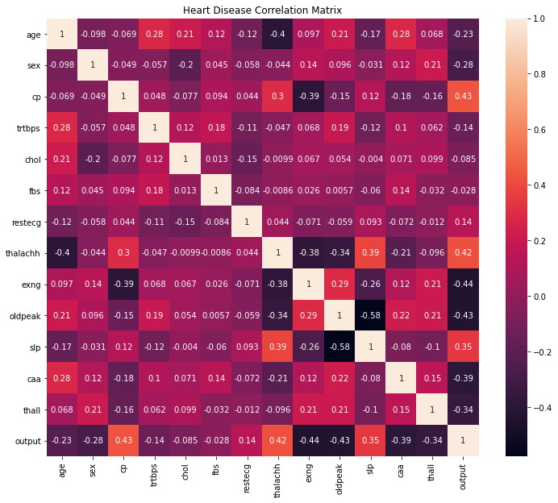

```python
# Use pandas build in correlation matrix function
corr = df.corr()
# Lets expand the dimensions of our figure, so it is easier to read
sn_dimensions = (12, 10)
# Plug the expanded dimensions into our pyplot
fig, ax = pyplot.subplots(figsize=sn_dimensions)
# Use seaborn to plot it
sn.heatmap(corr, annot = True)
# Show the plot
plt.title('Heart Disease Correlation Matrix')
plt.show()
```

### 3.4 Violin Plots

Distribution of data is extremely important, it gives us a great insight into what an "average" value in the dataset might be, and it might help us start to formalize hypotheses about why the data is distrbuted the way that it it is.

A great tool for visualizing distributions of data is [violin plots](https://en.wikipedia.org/wiki/Violin_plot) (follow up article at link). There are many ways to visualize data distrbutions, but violin plots are nice because they are very easy to read, and quite easy to code up with matplotlib and seaborn.

Let's take the time to visualize some of the variables that showed up high in the correlation matrix. The dependent variables Cp (chest pain) and thalachh (resting heart rate) both appear to be strongly correlated with heart disease. I also just intuitively think that age and sex will be as well, despite the correlation matrix stating otherwise. Let's draw violin plots for these variables.

#### Note: Violin plots in Seaborn VS Matplotlib

[Violin plots](https://en.wikipedia.org/wiki/Violin_plot) (follow up article at link) functions are available in both seaborn and matplotlib. I chose matplotlib for this section because I did not like how seaborn's violin plots show their distribution violins beyond actual min and max values in the distribution. The inside of the violin, the box and whisker, is the actual value but the violins that sometimes go above and beyond the max values are not very intuitive. I think they're hard to read. For example, when a seaborn violin plot's violin shows that resting heart rates below 0, that is quite confusing. You had to look at the boxplot inside the actual violin to understand the graph. I thought this was extremely counter intuitive, and decided to go with matplotlib for this part of the tutorial.

#### 3.4.1 Step by Step Code Walk-through

Matplotlib isn't as nice as seaborn, matplotlib was a library wrote in the 90s and is quite dated. So, [matplotlib violin plots](https://matplotlib.org/stable/api/_as_gen/matplotlib.axes.Axes.violinplot.html) (follow up article at link) require a little bit of heavier lifting on the user's part, compared to the nicer one-liner [seaborn violin plot](https://seaborn.pydata.org/generated/seaborn.violinplot.html) (follow up article at link) functions. However, never fret, we got this!

1. We need to group the values we want to plot. Violin plots shine when they can be used for grouped data. The easiest way to group data is to use a dictionary and separate values based on whatever group we want on the x-axis.
2. Once we have the points separated, we just call matplotlib's violinplot() function and pass in the data from our dictionary, along with the associated position array for the plots
3. Lastly, we clean up the plot by adjusting the x-axis and y-axis ticks, then add labels and title (if needed).

We can copy and paste the code we wrote, then just change the parameters of the x-axis and y-axis as needed.

#### 3.4.2 Chest Pain VS Heart Disease

We can see from this violin plot below, that a majority of the "no heart disease" observations have asymtopmatic pain. We also see a majority of the heart disease observations have their chest pain distributed around atypical angina. This makes sense, however you would also think there would be a large number of typical angina pain as well, which is surprising. But that may mean there are other factors at play here other than just chest pain that we may uncover further in our analysis

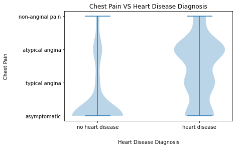

```python
dictionary = {}
dictionary[0.0] = []
dictionary[1.0] = []
for i,x in df.iterrows():
    dictionary[x['output']].append(x['cp'])
plt.title('Chest Pain VS Heart Disease Diagnosis')
plt.xticks([0,1],['no heart disease','heart disease'])
plt.yticks([0,1,2,3],['asymptomatic','typical angina','atypical angina','non-anginal pain'])
plt.ylabel("Chest Pain", labelpad=20)
plt.xlabel("Heart Disease Diagnosis",labelpad=20)
plt.violinplot(dictionary.values(), [0.0,1.0])
plt.show()
```

#### 3.4.3 Maximum Heart Rate VS Heart Disease

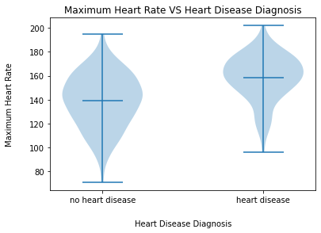

```python
dictionary = {}
dictionary[0.0] = []
dictionary[1.0] = []
for i,x in df.iterrows():
    dictionary[x['output']].append(x['thalachh'])
plt.title('Maximum Heart Rate VS Heart Disease Diagnosis')
plt.xticks([0,1],['no heart disease','heart disease'])
plt.ylabel("Maximum Heart Rate", labelpad=20)
plt.xlabel("Heart Disease Diagnosis",labelpad=20)
plt.violinplot(dictionary.values(), [0.0,1.0],showmeans=True)
plt.show()
```

#### 3.4.4 Age VS Heart Disease

The result below is extremely counterintuitive. We may uncover why this is the case later in the analysis.

One possibility worth discussing is that there may be a kind of survivorship bias at play here and I think it is a logical assumption. If your chest didn't hurt, and you were relatively young, would you go for an ECG? Probably not. However, if your chest did hurt, you probably would. We might be seeing a case like that happening here, where younger patients just aren't getting checked by their doctors for chest pain.

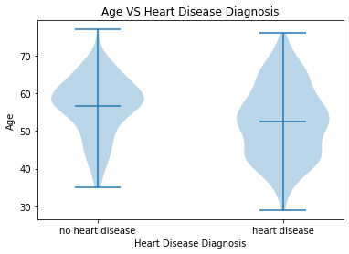

```python
dictionary = {}
dictionary[0.0] = []
dictionary[1.0] = []
for i,x in df.iterrows():
    dictionary[x['output']].append(x['age'])
plt.title('Age VS Heart Disease Diagnosis')
plt.xticks([0,1],['no heart disease','heart disease'])
plt.ylabel("Age")
plt.xlabel("Heart Disease Diagnosis")
plt.violinplot(dictionary.values(), [0.0,1.0], showmeans=True)
plt.show()
```

#### 3.4.5 Sex VS Heart Disease

The results here are quite surprising. Men are twice more likely than women to have a heart attack according to Harvard. We see here that almost all the negative heart disease diagnoses were from men. Again, this might be some form survivorship bias where the men are going to get checked out before they have symptoms as a preventative measure, and the women aren't.

We do see in the people diagnosed with heart disease that the men slightly outweigh the women, and this is roughly consistently with medical literature on heart disease. However, we would expect to see about twice the number of men and we see only about 1 and 1/2 times the amount of men, but this doesn't raise any of our data science alarms or red flags.

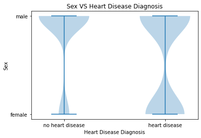

```python
dictionary = {}
dictionary[0.0] = []
dictionary[1.0] = []
for i,x in df.iterrows():
    dictionary[x['output']].append(x['sex'])
plt.title('Sex VS Heart Disease Diagnosis')
plt.xticks([0,1],['no heart disease','heart disease'])
plt.yticks([0,1],['female','male'])
plt.ylabel("Sex")
plt.xlabel("Heart Disease Diagnosis")
plt.violinplot(dictionary.values(), [0.0,1.0])
plt.show()
```

#### 3.4.6 Slope of peak exercise ST segment VS Heart Disease

The results here are consistent with what we would expect, but still a little off. We know during exercise a normal ST segment is flat or slopes downwards. A person with heart disease's segment will slope sharply upwards during exercise (a value of 2 in this case). We would expect there to be less flat ST segments for people diagnosed with heart diseases, but it isn't very significant

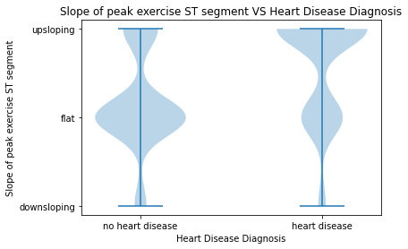

```python
dictionary = {}
dictionary[0.0] = []
dictionary[1.0] = []
for i,x in df.iterrows():
    dictionary[x['output']].append(x['slp'])
plt.title('Slope of peak exercise ST segment VS Heart Disease Diagnosis')
plt.xticks([0,1],['no heart disease','heart disease'])
plt.yticks([0,1,2],['downsloping','flat', 'upsloping'])
plt.ylabel("Slope of peak exercise ST segment")
plt.xlabel("Heart Disease Diagnosis")
plt.violinplot(dictionary.values(), [0.0,1.0])
plt.show()
```

# Part 4: Hypothesis testing and machine learning

### 4.1 Hypothesis Testing

Data scientists usually form a hypothesis about their data, then test it using [statistical hypothesis testing](https://en.wikipedia.org/wiki/Statistical_hypothesis_testing) (follow up article at link), and either reject or accept their hypothesis.

Based on our correlation matrix that showed chest pain and resting heart rate as the strongest correlated variable dependent variables, and our violin plot distributions, we will hypothesize that is a relationship between chest pain, resting heart rate, and heart disease diagnosis.

#### 4.1.1 Statsmodels

[Statsmodels](https://www.statsmodels.org/stable/index.html) (follow up article at link) is a statistics library written in Python and can quickly show us p-values and R-squared values. We will be using [statsmodels ordinary least squares](https://www.statsmodels.org/stable/generated/statsmodels.regression.linear_model.OLS.html) (follow up article at link) linear regression. Statsmodels does not do any cross validation, and is not a machine learning library, we will only be using it here for R-squared and p-values.

#### 4.1.2 Step by Step Code-Walkthrough

Statmodels make it very easy for us, and we can do it in two lines of code. We broke it out into four lines of code declaring dependent and independent variables, respectively, just for ease of reading.

1. declare independent and dependent variables
2. invoke statsmodels ordinary least squares
3. display the summary of the model

#### 4.1.3 Chest Pain and Resting Heart Rate Linear Regression

It is quite feasible, using our intuition, that we anticipate a linear relationship between physiological measures and heart disease. Chest pain and resting heart rate would likely have a linear relationship to heart disease. The more your chest hurts the more likely something is probably wrong with your heart and the higher your resting heart rate the more likely there is something wrong with your heart.

We use statsmodels below to create a linear regression (without cross fold validation) and we see the [R-squared](https://en.wikipedia.org/wiki/Coefficient_of_determination) (follow up article at link) value is .655 which means the model explains roughly 65.5% of the data.

We also see the p-value is 0.0 which means using a significance level of 0.05 we can reject the null hypothesis and conclude there is a relationship between chest pain, resting heart rate, and heart disease.

```python
X = df[['cp', 'thalachh']]
y = df['output']
cp_thalachh_model = sm.OLS(y,X).fit()
cp_thalachh_model.predict(X)
cp_thalachh_model.summary()
```

OLS Regression Results

| Dep. Variable: | output | R-squared (uncentered): | 0.655 |
| --- | --- | --- | --- |
| Model: | OLS | Adj. R-squared (uncentered): | 0.653 |
| Method: | Least Squares | F-statistic: | 286.2 |
| Date: | Sat, 15 May 2021 | Prob (F-statistic): | 2.39e-70 |
| Time: | 12:47:14 | Log-Likelihood: | -176.48 |
| No. Observations: | 303 | AIC: | 357.0 |
| Df Residuals: | 301 | BIC: | 364.4 |
| Df Model: | 2 |  |  |
| Covariance Type: | nonrobust |  |  |

|  | coef | std err | t | P>\|t\| | [0.025 | 0.975] |
| --- | --- | --- | --- | --- | --- | --- |
| cp | 0.1793 | 0.025 | 7.156 | 0.000 | 0.130 | 0.229 |
| thalachh | 0.0026 | 0.000 | 11.023 | 0.000 | 0.002 | 0.003 |

| Omnibus: | 100.333 | Durbin-Watson: | 0.354 |
| --- | --- | --- | --- |
| Prob(Omnibus): | 0.000 | Jarque-Bera (JB): | 17.232 |
| Skew: | -0.179 | Prob(JB): | 0.000181 |
| Kurtosis: | 1.888 | Cond. No. | 152. |

Notes:  
[1] R² is computed without centering (uncentered) since the model does not contain a constant.  
[2] Standard Errors assume that the covariance matrix of the errors is correctly specified.

#### 4.1.4 Chest Pain and Resting Heart Rate Linear Regression Residuals

We can see the R-squared value is good, but we would expect there to be a stronger relationship. Let's explore the residuals of the model against age and sex (other parameter that appeared to influence the diagnoses of heart disease in our exploratory phase).

#### Note: Seaborn VS Matplotlib

[Seaborn violin plots](https://seaborn.pydata.org/generated/seaborn.violinplot.html) (follow up article at link) have an interesting way to show the distribution. Vhe actual violin shape that shows the distribution extends beyond the data's max and minimum points. You have to look at the box and whisker plot inside the violin to see the actual bounds. However, when we were plotting nonzeros values, and saw the violins going below zeros in part 3 that was quite confusing.

However, in part 4, we are plotting [residual values](https://en.wikipedia.org/wiki/Residual_value) (follow up article at link) which are an estimate of our linear regression models performance. Residuals are expected to sometimes be below 0, and that's okay. Seaborn makes it much easier to plot the residuals because we can skip the grouping phase we had to do in matplotlib which makes more cleaner and easier code. So we're going to jump into seaborn for this section. Which is good, because it gives the reader experience with both libraries!

#### 4.1.5 Code walk through

The code below does the following:

1. We use [pandas cut](https://pandas.pydata.org/docs/reference/api/pandas.cut.html) to split age into equal bins
   1. Pandas cut takes a bins argument which we are passing a scalar value. The scalar value starts at the minimum age, goes to the maximum age+1 because pythons range() upper bound is exclusive, then the range of age divided by 4 because it works out to even bins of length of 12 years
2. Seaborn makes it quite easy to plot residuals using bins, so we'll it here. Just one line of seaborn code, then some labels

#### 4.1.6 Residuals of Chest Pain and Resting Heart Rate Linear Regression grouped by Age

Conclusion: We can see a linear relationship of the residuals, age needs to be taken into account when creating a model.

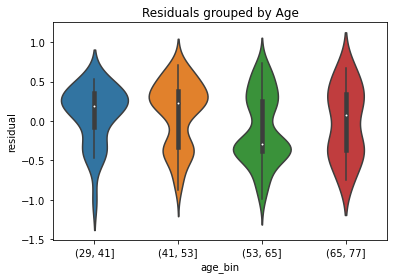

```python
# Get linear regression residuals
df['residual'] = cp_thalachh_model.resid
# Create equal sized age bins
age_min = df['age'].min()
age_max = df['age'].max()
df['age_bin'] = pd.cut(df['age'],bins=range(age_min,age_max+1,(age_max-age_min)//4))
# Create seaborn residuals plot grouped against age
ax = sn.violinplot(x=df['age_bin'],y=df['residual'])
ax.set_title('Residuals grouped by Age')
plt.show()
```

#### 4.1.7 Residuals of Chest Pain and Resting Heart Rate Linear Regression grouped by Sex

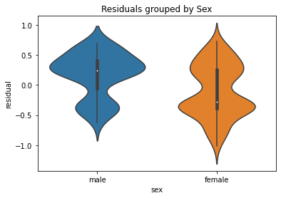

```python
# Create seaborn residuals plot grouped against sex
ax = sn.violinplot(x=df['sex'],y=df['residual'])
ax.set_xticklabels(['male','female'])
ax.set_title('Residuals grouped by Sex')
plt.show()
```

#### 4.1.8 Residuals Chest Pain and Resting Heart Rate Linear Regression grouped by Slope of peak exercise ST segment

When grouping and plotting the residuals by ST segment we our model does underestimate for downsloping and flat, but not for upsloping. This makes sense and supports the fact that downsloping and flat ST segments are indicative of no heart disease.

Conclusion: I do not see a strong enough relationship in SLP to add this to a new model.

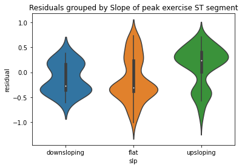

```python
# Create seaborn residuals plot grouped against SLP
ax = sn.violinplot(x=df['slp'],y=df['residual'])
ax.set_xticklabels(['downsloping','flat','upsloping'])
ax.set_title('Residuals grouped by Slope of peak exercise ST segment')
plt.show()
```

#### 4.1.9 Chest Pain, Resting Heart Rate, and Sex Linear Regression

We can see from the violin plots of the residuals above that sex needs to be considered, let's repeat the code and process we used above to create another linear regression.

We can see the p-value are still under our significance level. Additionally, our R-squared value indicates our model now explains almost 70% of the data.

```python
X = df[['sex', 'cp', 'thalachh']]
y = df['output']
sexcpthalachh = sm.OLS(y,X).fit()
sexcpthalachh.predict(X)
sexcpthalachh.summary()
```

OLS Regression Results

| Dep. Variable: | output | R-squared (uncentered): | 0.694 |
| --- | --- | --- | --- |
| Model: | OLS | Adj. R-squared (uncentered): | 0.691 |
| Method: | Least Squares | F-statistic: | 226.9 |
| Date: | Sat, 15 May 2021 | Prob (F-statistic): | 7.78e-77 |
| Time: | 12:47:17 | Log-Likelihood: | -158.39 |
| No. Observations: | 303 | AIC: | 322.8 |
| Df Residuals: | 300 | BIC: | 333.9 |
| Df Model: | 3 |  |  |
| Covariance Type: | nonrobust |  |  |

|  | coef | std err | t | P>\|t\| | [0.025 | 0.975] |
| --- | --- | --- | --- | --- | --- | --- |
| sex | -0.3032 | 0.049 | -6.170 | 0.000 | -0.400 | -0.206 |
| cp | 0.1682 | 0.024 | 7.090 | 0.000 | 0.121 | 0.215 |
| thalachh | 0.0040 | 0.000 | 12.539 | 0.000 | 0.003 | 0.005 |

| Omnibus: | 32.406 | Durbin-Watson: | 0.574 |
| --- | --- | --- | --- |
| Prob(Omnibus): | 0.000 | Jarque-Bera (JB): | 10.252 |
| Skew: | -0.101 | Prob(JB): | 0.00594 |
| Kurtosis: | 2.122 | Cond. No. | 316. |

Notes:  
[1] R² is computed without centering (uncentered) since the model does not contain a constant.  
[2] Standard Errors assume that the covariance matrix of the errors is correctly specified.

#### 4.1.10 Chest Pain, Resting Heart Rate, and Age Linear Regression

We can see from the violin plots of the residuals above that age needs to be considered, let's repeat the code and process we used above to create another linear regression.

We can see the p-value are still under our significance level. Additionally, our R-squared value indicates our model now explains almost 68% of the data.

```python
X = df[['age', 'cp', 'thalachh']]
y = df['output']
agecpthalachh = sm.OLS(y,X).fit()
agecpthalachh.predict(X)
agecpthalachh.summary()
```

OLS Regression Results

| Dep. Variable: | output | R-squared (uncentered): | 0.675 |
| --- | --- | --- | --- |
| Model: | OLS | Adj. R-squared (uncentered): | 0.672 |
| Method: | Least Squares | F-statistic: | 207.8 |
| Date: | Sat, 15 May 2021 | Prob (F-statistic): | 6.50e-73 |
| Time: | 12:47:18 | Log-Likelihood: | -167.52 |
| No. Observations: | 303 | AIC: | 341.0 |
| Df Residuals: | 300 | BIC: | 352.2 |
| Df Model: | 3 |  |  |
| Covariance Type: | nonrobust |  |  |

|  | coef | std err | t | P>\|t\| | [0.025 | 0.975] |
| --- | --- | --- | --- | --- | --- | --- |
| age | -0.0072 | 0.002 | -4.276 | 0.000 | -0.011 | -0.004 |
| cp | 0.1694 | 0.024 | 6.917 | 0.000 | 0.121 | 0.218 |
| thalachh | 0.0052 | 0.001 | 7.968 | 0.000 | 0.004 | 0.006 |

| Omnibus: | 17.894 | Durbin-Watson: | 0.522 |
| --- | --- | --- | --- |
| Prob(Omnibus): | 0.000 | Jarque-Bera (JB): | 7.822 |
| Skew: | -0.132 | Prob(JB): | 0.0200 |
| Kurtosis: | 2.259 | Cond. No. | 162. |

Notes:  
[1] R² is computed without centering (uncentered) since the model does not contain a constant.  
[2] Standard Errors assume that the covariance matrix of the errors is correctly specified.

#### 4.1.11 Residuals of Chest Pain, Resting Heart Rate, and Sex Linear Regression grouped by Age

We can repeat the code we used above to create age bins to group the residuals of our new model by age.

We can see from this graph below that our residuals has significantly improved for the age group 65 - 77. However, the other age groups did not improve much.

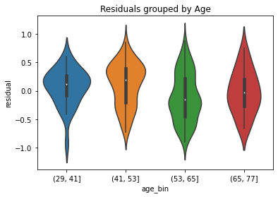

```python
df['residual']=sexcpthalachh.resid
ax = sn.violinplot(x=df['age_bin'],y=df['residual'])
ax.set_title('Residuals grouped by Age')
plt.show()
```

#### 4.1.12 Residuals of Chest Pain, Resting Heart Rate, and Age Linear Regression grouped by Sex

We can again repeat the code from above to plot the residuals grouped by sex. We can see that the residuals has not improved much, the male residuals has come down slightly and so has female, but it is not very significant like age was.

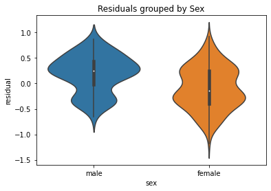

```python
df['residual']=agecpthalachh.resid
ax = sn.violinplot(x=df['sex'],y=df['residual'])
ax.set_title('Residuals grouped by Sex')
ax.set_xticklabels(['male','female'])
plt.show()
```

#### 4.1.13 Residuals of Chest Pain, Resting Heart Rate, and Sex Linear Regression grouped by Slope of peak exercise ST segment

We can see the residuals for our new model that includes sex is much more accurate, the residuals for downsloping, flat, and upsloping have all improved and sex helps explain ST segments better in regards to heart disease.

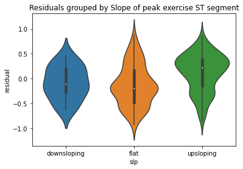

```python
df['residual'] = sexcpthalachh.resid
ax = sn.violinplot(x=df['slp'],y=df['residual'])
ax.set_xticklabels(['downsloping','flat','upsloping'])
ax.set_title('Residuals grouped by Slope of peak exercise ST segment')
plt.show()
```

#### 4.1.13 Residuals of Chest Pain, Resting Heart Rate, and Age Linear Regression grouped by Slope of peak exercise ST segment

The new linear model that includes age did not appear to improve the residuals much, they are roughly the same, meaning our model did not get better at explaining ST segments in regards to heart disease.

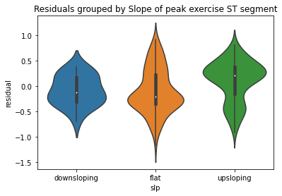

```python
df['residual'] = agecpthalachh.resid
ax = sn.violinplot(x=df['slp'],y=df['residual'])
ax.set_xticklabels(['downsloping','flat','upsloping'])
ax.set_title('Residuals grouped by Slope of peak exercise ST segment')
plt.show()
```

### 4.2 Machine Learning

As discussed briefly in the hypothesis testing, I think it is very plausible to assume that there is a linear relationship between physiological metrics and heart disease. I do not think this is a complicated enough relationship to warrant a polynomial relationship or model. We even see linear relationships in the residuals above. Yes, we could employ more complex models like kmeans clustering, but I do not think it is necessary.

We have seen good success as seen above with just a basic OLR linear regression, and this without doing any kind of cross-validation) (see link for article), because statsmodels is a closed model ordinary least squares algorithm that does not do any employ any cross fold validation under the hood. Hopefully, once we do employ some machine learning and do some cross-validation, we will see our accuracy improve.

#### 4.2.1 Linear Regression with sklearn

[Sklearn](https://scikit-learn.org/stable/), like statsmodels, uses a closed model ordinary least squares method which is based on [scipy's](https://www.scipy.org/) Linear Regression. However, lets give it a try and see what we come up with! Sklearn is a little less intuitive than statsmodels, and that's why we've been avoiding it until this point. However, understanding how sklearn's linear regression works will be a good precursor to cross-validation in the subsequent section.

The result, is that it appears like sklearn actually does a better job of predicting residuals for ages 53-77, but the age groups 29-53 still appear to have poor residuals.

#### Step by Step Code-Walkthrough

1. Drop na values to avoid the algorithm falsely predicting
2. Create an array of input features
3. Use numpy's vstack function to create a sequenced of arrays stacked vertically to use with sklearn
4. Use numpy's transpose to reverse the axes of the array
5. Use sklearn's Linear Regression, and fit it with our data
6. Calculte the residuals of the linear model by hand
7. Plot the residuals in seaborn, exactly how we did in the earlier sections

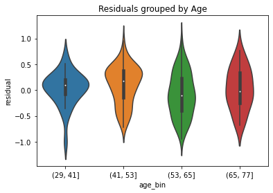

```python
# For linear regression we will drop rows with NaN values, if they exist
# (this is just a precautionary measure, we did this earlier)
data = df.dropna().copy()

# Isolate the features that will be used as predictors
features = [
    data['sex'],
    data['cp'],
    data['thalachh']
]
features = np.vstack(features)
features = features.transpose()

# Fit a model for predicting output
model = LinearRegression().fit(features, data['output'])


# Calculate the residual for each row in the dataframe
for index, row in data.iterrows():
    data.loc[index, "residual"] = row["output"] - model.predict(np.array([
                                                      data['sex'][index],
                                                      data['cp'][index],
                                                      data['thalachh'][index]
                                                  ]).reshape(1, -1))

# Make a violin plot of mmse model residuals vs. SES
ax = sn.violinplot(x=data['age_bin'], y=data['residual'])
ax.set_title('Residuals grouped by Age')
plt.show()
```

#### 4.2.1 Kfolds Cross-Validation Linear Regression with sklearn

Now, let's do some real machine learning. cross-validation) (see link for article) is a popular machine learning technique that splits your dataset into a training dataset and a testing dataset. You train your machine learning model with the training set, then use the testing dataset to verify the predictions.

Kfolds splits data into multiple cross-validation sets and trains/tests with multiple segments of the data and results in a more robuts model. Lets use them in combination below.

#### Step by Step Code-Walkthrough

We will be splitting into train and test data. We will train our model with training data, then use our model to predict values in our test data.

1. We will create a new dataframe with the data just for ease of use (we have a lot of residual columsn, age_bins, etc.)
2. split into train and test data
3. use kfolds to create a cross-validation scheme
4. specify the range of hypermaraters we will let the model tune
5. gather the input features for the model
6. use numpy to stack and transpose the parameters
7. fit our training data with out linear regression
8. feed our model into the sklearn recursive feature elimination algorithm
9. use grid search CV to optimize our parameters and fit the model
10. calculate residuals using test data (using model trained with testing) and graph using seaborn

```
Fitting 5 folds for each of 12 candidates, totalling 60 fits
```

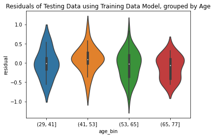

```python
# create fresh data frame with existing residuals
data = df.drop(['residual', 'age_bin'],axis=1).copy()

# train / test split for cross_validation
df_train, df_test = train_test_split(data,
                                     train_size = 0.7,
                                     test_size = 0.3,
                                     random_state = 100)

# create independent and dependent variables
y_train = data.pop('output')
X_train = data


# create a cross-validation scheme
folds = KFold(n_splits = 5, shuffle = True, random_state = 100)

# specify range of hyperparameters to tune
hyper_params = [{'n_features_to_select': list(range(1, 13))}]

# gather input features
features = [
    df_train['sex'],
    df_train['cp'],
    df_train['thalachh'],
    df_train['trtbps'],
    df_train['chol'],
    df_train['fbs'],
    df_train['restecg'],
    df_train['thalachh'],
    df_train['exng'],
    df_train['oldpeak'],
    df_train['slp'],
    df_train['caa'],
    df_train['thall'],
]
features = np.vstack(features)
features = features.transpose()

# create linear regression
lm = LinearRegression().fit(features, df_train['output'])
lm.fit(X_train, y_train)
# recursive feature elimination
rfe = RFE(lm).fit(features, df_train['output'])

# # 3.2 call GridSearchCV()
model_cv = GridSearchCV(estimator = rfe,
                        param_grid = hyper_params,
                        scoring= 'r2',
                        cv = folds,
                        verbose = 1,
                        return_train_score=True)

# fit the model
clf = model_cv.fit(features, df_train['output'])
# Calculate the residual for each row in the dataframe using test data
y_pred = []
for index, row in df_test.iterrows():
    data.loc[index, "residual"] = row["output"] - clf.predict(np.array([
                                                      df_test['sex'][index],
                                                      df_test['cp'][index],
                                                      df_test['thalachh'][index],
                                                      df_test['trtbps'][index],
                                                      df_test['chol'][index],
                                                      df_test['fbs'][index],
                                                      df_test['restecg'][index],
                                                      df_test['thalachh'][index],
                                                      df_test['exng'][index],
                                                      df_test['oldpeak'][index],
                                                      df_test['slp'][index],
                                                      df_test['caa'][index],
                                                      df_test['thall'][index],
                                                  ]).reshape(1, -1))

# Create equal sized age bins
age_min = df_train['age'].min()
age_max = df_train['age'].max()
data['age_bin'] = pd.cut(data['age'],bins=range(age_min,age_max+1,(age_max-age_min)//4))

# Make a violin plot of residuals VS age
ax = sn.violinplot(x=data['age_bin'], y=data['residual'])
ax.set_title('Residuals of Testing Data using Training Data Model, grouped by Age')
plt.show()
```

### 4.2.1 ML Results

We can see from our model's residuals above, that after we utilized cross-validation kfolds we have slightly improved our residuals across the board. Specifically, we finally now have a good predictors for the ages from 29-41. Additionally we greatly improved the residuals of the model for ages 53-65, however tehre is still a bit of a negative residual tail which mean it could be improved. Lastly, the model for 65-77 looks great, it is very tight with no large tail, however it still appears looking at the box plot inside the violin that it is still underestimating heart disease because the residuals are negative.

However, all the models residuals are significantly improved over the normal linear regression using statsmodels and sklearn without cross-validation.

# Part 5: Communication of insights attained

We taught the reader quite a bit about the entire data science pipeline, pandas, sklearn, statsmodels, seaborn, and matplotlib. We (and hopefully the reader!) also picked up quite a bit of domain knowledge about heart disease.

Overall, we have demonstrated that predicting heart disease is very possible, based on the residuals of our final machine learning model. The accuracy we demonstrated points towards the fact that predictions are completely feasible and can be accurate. Additionally, with a richer dataset and more refinement of our models/approaches we can definitely predict heart disease with likely even higher accuracy!

We saw observed some data points that went against the literature and our intuition. The two observations were related to age and sex.

We also saw it looks like chest pain, maximum heart rate, and sex are the strongest predictors and parameters that should be used in a model to predict heart disease; we also saw that (at least with this data) that age, cholesterol, ECG results, and fasting blood sugar are not great predictors of heart disease.

Further work needs to be done to find more datasets and merdge them into then further verify our findings. A person reading this tutorial could go and find a new dataset and repeat these steps and see if you can create a model with simila residuals. Additionally, when exploring the new dataset, we would suggest exploring these two abnormal observations in this dataset (sex and age) hold true across that new dataset and multiple datasets on heart disease. We also could work on refining our models and our machine learning approaches too.

##### Please checkout all of the hyperlinks in this article for further reading resources to continue learning, and good luck!